# Traitement BFC FEDERFSE méthode basée sur une approche empirique

Document de travail - d-sidd

Juin 2024

## Les écarts sur deux dimensions

Nous pouvons considérer les écarts associés aux postes des dépenses en deux dimensions:

- Le montant moyen écarté d’un poste
- L’écart relatif entre montant présenté et montant écarté

Grossièrement, un poste au dessus de ces 2 seuils peut être qualifié de poste à écart important.

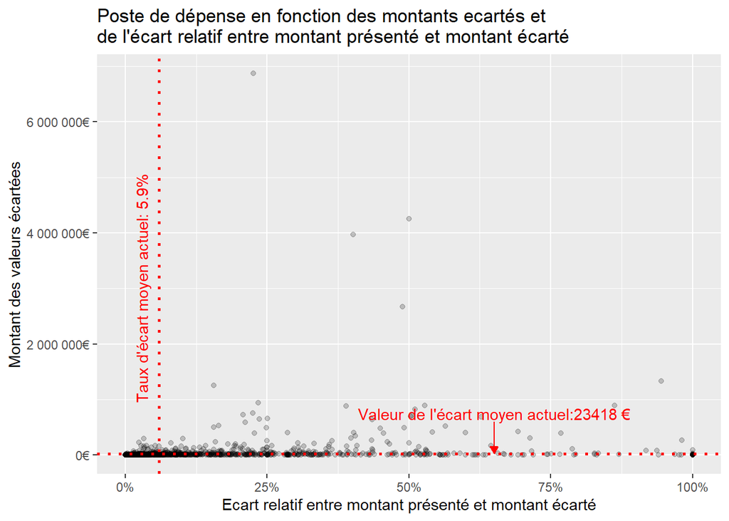

### Caractériser les écarts

Nous proposons de définir deux niveaux d’écarts avec les ègles suivantes:

- **Ecart minime ou modéré**:

Les deux conditions suivantes sont vérifiées:

```
+ L'écart relatif entre montant présenté et montant écarté: < 5%
+ Le montant moyen écarté d'un poste: <100 000 €
```

- **Ecart important ou très important**:

L’une ou l’autre des conditions suivantes est vérifiée:

```
+ L'écart relatif entre montant présenté et montant écarté: >5%
+ Le montant moyen écarté d'un poste: >100 000 €
```

Nous obtenons ainsi la répartition suivante des postes de dépenses en fonction du profil de’écart:

| profil_ecart | Nombre de postes | Montant écarté | Part de postes | Part du montant écarté |
| --- | --- | --- | --- | --- |
| Ecart minime ou modéré | 1919 | 3249099 | 73.6% | 5.3% |
| Ecart important ou très important | 687 | 57779170 | 26.4% | 94.7% |

Nous pouvons observer que 94.7% des montants écartés sont concentrés sur 26.4% des postes.

Ainsi, être en capacité d’identifier les profils à écarts important et très important (26.4% des postes) permettrait d’isoler potentiellement 94.7% des montants écartés.

## Score par modalités sur les variables sélectionnées

### G1_Dep_Poste

| Score | G1_Dep_Poste | Nombre de postes | Montant total | Montant écarté | Montant moyen écarté | Part du montant écarté | Taux moyen écarté |
| --- | --- | --- | --- | --- | --- | --- | --- |
| 1 | Dépenses d’amortissement | 8 | 869 503€ | 3 743€ | 468€ | 0.0% | 0.4% |
| 2 | Dépenses d’Investissement matériel et immatériel | 719 | 646 463 648€ | 33 673 121€ | 46 833€ | 55.2% | 5.2% |
| 2 | Dépenses de fonctionnement (frais généraux de structure) | 37 | 1 342 781€ | 53 181€ | 1 437€ | 0.1% | 4.0% |
| 2 | Dépenses de personnel | 551 | 89 413 337€ | 5 124 098€ | 9 300€ | 8.4% | 5.7% |
| 2 | Dépenses de prestations externes de service | 972 | 198 154 727€ | 13 024 541€ | 13 400€ | 21.3% | 6.6% |
| 3 | Autres dépenses (à spécifier) | 198 | 93 217 918€ | 8 865 365€ | 44 775€ | 14.5% | 9.5% |
| 3 | Dépenses de communication de l’opération | 93 | 1 129 310€ | 133 755€ | 1 438€ | 0.2% | 11.8% |
| 3 | Dépenses en nature | 28 | 1 949 174€ | 150 466€ | 5 374€ | 0.2% | 7.7% |

| Score | Nombre de postes | Montant total | Montant écarté | Montant moyen écarté | Part du montant écarté | Taux moyen écarté |
| --- | --- | --- | --- | --- | --- | --- |
| 1 | 8 | 869 503€ | 3 743€ | 468€ | 0.0% | 0.4% |
| 2 | 2279 | 935 374 494€ | 51 874 941€ | 22 762€ | 85.0% | 5.5% |
| 3 | 319 | 96 296 402€ | 9 149 586€ | 28 682€ | 15.0% | 9.5% |

### G2_Proj_cl_ProjetMontant

| Score | G2_Proj_cl_ProjetMontant | Nombre de postes | Montant total | Montant écarté | Montant moyen écarté | Part du montant écarté | Taux moyen écarté |
| --- | --- | --- | --- | --- | --- | --- | --- |
| 0.5 | 01_[629,60000) | 396 | 10 556 498€ | 502 454€ | 1 269€ | 0.8% | 4.8% |
| 1.0 | 02_[60000,106000) | 394 | 22 572 063€ | 961 620€ | 2 441€ | 1.6% | 4.3% |
| 1.5 | 03_[106000,194000) | 436 | 39 363 329€ | 1 843 517€ | 4 228€ | 3.0% | 4.7% |
| 2.0 | 04_[194000,375000) | 494 | 74 800 010€ | 2 831 969€ | 5 733€ | 4.6% | 3.8% |
| 2.5 | 05_[375000,735000) | 429 | 146 837 339€ | 7 832 208€ | 18 257€ | 12.8% | 5.3% |
| 3.0 | 06_[735000,2000000) | 306 | 213 306 206€ | 15 200 552€ | 49 675€ | 24.9% | 7.1% |
| 3.5 | 07_[2000000,48551690] | 151 | 525 104 954€ | 31 855 950€ | 210 967€ | 52.2% | 6.1% |

| Score | Nombre de postes | Montant total | Montant écarté | Montant moyen écarté | Part du montant écarté | Taux moyen écarté |
| --- | --- | --- | --- | --- | --- | --- |
| 0.5 | 396 | 10 556 498€ | 502 454€ | 1 269€ | 0.8% | 4.8% |
| 1.0 | 394 | 22 572 063€ | 961 620€ | 2 441€ | 1.6% | 4.3% |
| 1.5 | 436 | 39 363 329€ | 1 843 517€ | 4 228€ | 3.0% | 4.7% |
| 2.0 | 494 | 74 800 010€ | 2 831 969€ | 5 733€ | 4.6% | 3.8% |
| 2.5 | 429 | 146 837 339€ | 7 832 208€ | 18 257€ | 12.8% | 5.3% |
| 3.0 | 306 | 213 306 206€ | 15 200 552€ | 49 675€ | 24.9% | 7.1% |
| 3.5 | 151 | 525 104 954€ | 31 855 950€ | 210 967€ | 52.2% | 6.1% |

### G3_Team_TypeTerriteo

| Score | G3_Team_TypeTerriteo | Nombre de postes | Montant total | Montant écarté | Montant moyen écarté | Part du montant écarté | Taux moyen écarté |
| --- | --- | --- | --- | --- | --- | --- | --- |
| 1 | Autre regroupement public (Syndicat mixte / intercommunal, GIP, Organisme consulaire, Office public de l’habitat.) | 289 | 89 775 051€ | 3 828 712€ | 13 248€ | 6.3% | 4.3% |
| 1 | Département | 22 | 107 291 221€ | 125 399€ | 5 700€ | 0.2% | 0.1% |
| 1 | Région | 544 | 142 311 688€ | 2 774 808€ | 5 101€ | 4.5% | 1.9% |
| 1 | Établissement d’hospitalisation | 37 | 20 847 535€ | 1 073 963€ | 29 026€ | 1.8% | 5.2% |
| 1 | Établissement public national à caractère scientifique culturel et professionnel | 262 | 30 891 836€ | 705 288€ | 2 692€ | 1.2% | 2.3% |
| 2 | Association / syndicat professionnel | 435 | 57 291 063€ | 4 286 568€ | 9 854€ | 7.0% | 7.5% |
| 2 | Commune de plus de 10 000 habitants | 71 | 47 306 999€ | 3 461 517€ | 48 754€ | 5.7% | 7.3% |
| 2 | EPCI de taille modeste (- de 50 000 habitants) | 37 | 9 707 654€ | 985 439€ | 26 633€ | 1.6% | 10.2% |
| 2 | EPCI important (+ de 50 000 habitants) | 55 | 88 962 881€ | 4 194 864€ | 76 270€ | 6.9% | 4.7% |
| 2 | Etablissement public (ONF, EPLEFPA, EPIC, EPLEA, etc.) | 194 | 18 111 071€ | 1 385 150€ | 7 140€ | 2.3% | 7.6% |
| 2 | Société (SA, SAS, SARL, SCI, etc.) | 535 | 377 961 648€ | 30 878 384€ | 57 717€ | 50.6% | 8.2% |
| 3 | Commune de moins de 10 000 habitants | 103 | 29 192 111€ | 5 276 059€ | 51 224€ | 8.6% | 18.1% |
| 3 | SEM | 22 | 12 889 640€ | 2 052 118€ | 93 278€ | 3.4% | 15.9% |

| Score | Nombre de postes | Montant total | Montant écarté | Montant moyen écarté | Part du montant écarté | Taux moyen écarté |
| --- | --- | --- | --- | --- | --- | --- |
| 1 | 1154 | 391 117 332€ | 8 508 171€ | 7 373€ | 13.9% | 2.2% |
| 2 | 1327 | 599 341 316€ | 45 191 922€ | 34 056€ | 74.1% | 7.5% |
| 3 | 125 | 42 081 751€ | 7 328 177€ | 58 625€ | 12.0% | 17.4% |

### G4_Axe_libPI

| Score | G4_Axe_libPI | Nombre de postes | Montant total | Montant écarté | Montant moyen écarté | Part du montant écarté | Taux moyen écarté |
| --- | --- | --- | --- | --- | --- | --- | --- |
| 1 | AT_Assistance Technique (tous fonds) | 20 | 28 005 973€ | 10 762€ | 538€ | 0.0% | 0.0% |
| 1 | PI 1.a_Infrastructures de recherche et d’innovation (R&I) | 254 | 36 602 126€ | 727 855€ | 2 866€ | 1.2% | 2.0% |
| 1 | PI 1.b_Favoriser les investissements des entreprises dans R&I, | 193 | 44 741 777€ | 1 857 931€ | 9 627€ | 3.0% | 4.2% |
| 1 | PI 10.iii.a_Connaissance de base (FSE) | 54 | 6 061 259€ | 235 394€ | 4 359€ | 0.4% | 3.9% |
| 1 | PI 10.iii.b_Formation des demandeurs d’emplois et des actifs (FSE) | 572 | 110 852 657€ | 2 893 598€ | 5 059€ | 4.7% | 2.6% |
| 1 | PI 10.iii.d_Apprentissage (FSE) | 148 | 13 139 826€ | 732 796€ | 4 951€ | 1.2% | 5.6% |
| 1 | PI 2.a_Déploiement Très haut débit | 7 | 120 389 945€ | 173 551€ | 24 793€ | 0.3% | 0.1% |
| 1 | PI 2.c_Applications TIC | 91 | 32 274 447€ | 1 137 060€ | 12 495€ | 1.9% | 3.5% |
| 1 | PI 8.ii_NEETS (IEJ) | 65 | 10 598 683€ | 470 551€ | 7 239€ | 0.8% | 4.4% |
| 2 | PI 12.a_Investissements dans services de santé | 5 | 4 970 109€ | 333 328€ | 66 666€ | 0.5% | 6.7% |
| 2 | PI 3.a_Esprit d’entreprise, création d’entreprises | 79 | 13 439 352€ | 1 208 277€ | 15 295€ | 2.0% | 9.0% |
| 2 | PI 3.d Massif du Jura_Capacité des PME à croître | 31 | 15 839 381€ | 1 028 149€ | 33 166€ | 1.7% | 6.5% |
| 2 | PI 3.d_Capacité des PME à croître | 380 | 301 447 971€ | 25 196 850€ | 66 308€ | 41.3% | 8.4% |
| 2 | PI 4.c_Efficacité énergétique, gestion intelligente de l’énergie | 74 | 51 531 436€ | 3 827 217€ | 51 719€ | 6.3% | 7.4% |
| 2 | PI 4.e_Stratégies faible émission de carbone (dont Transports durables) | 71 | 69 538 959€ | 3 827 855€ | 53 913€ | 6.3% | 5.5% |
| 2 | PI 6.c Massif du Jura_Patrimoine naturel et culturel | 63 | 18 703 683€ | 1 484 597€ | 23 565€ | 2.4% | 7.9% |
| 2 | PI 6.e_Environnement urbain, friches industrielles | 36 | 50 866 008€ | 4 493 251€ | 124 813€ | 7.4% | 8.8% |
| 2 | PI 9.b_Revitalisation en zones urbaines et rurales | 25 | 21 614 237€ | 1 304 470€ | 52 179€ | 2.1% | 6.0% |
| 3 | PI 10.iii.c_Orientation (FSE) | 25 | 1 470 943€ | 179 032€ | 7 161€ | 0.3% | 12.2% |
| 3 | PI 4.a_Production et distribution d’EnR | 144 | 51 153 591€ | 6 253 773€ | 43 429€ | 10.2% | 12.2% |
| 3 | PI 4.e_Stratégies de développement à faible émission de carbone (dont Transports durables) | 18 | 8 081 844€ | 1 168 344€ | 64 908€ | 1.9% | 14.5% |
| 3 | PI 6.d_Protection et restauration de la biodiversité | 251 | 21 216 193€ | 2 483 629€ | 9 895€ | 4.1% | 11.7% |

| Score | Nombre de postes | Montant total | Montant écarté | Montant moyen écarté | Part du montant écarté | Taux moyen écarté |
| --- | --- | --- | --- | --- | --- | --- |
| 1 | 1404 | 402 666 693€ | 8 239 498€ | 5 869€ | 13.5% | 2.0% |
| 2 | 764 | 547 951 136€ | 42 703 994€ | 55 895€ | 70.0% | 7.8% |
| 3 | 438 | 81 922 571€ | 10 084 777€ | 23 025€ | 16.5% | 12.3% |

### G5_Aide_AideEtat

| Score | G5_Aide_AideEtat | Nombre de postes | Montant total | Montant écarté | Montant moyen écarté | Part du montant écarté | Taux moyen écarté |
| --- | --- | --- | --- | --- | --- | --- | --- |
| 1 | Sans aide d’Etat | 1814 | 412 023 384€ | 22 818 763€ | 12 579€ | 37.4% | 5.5% |
| 2 | Avec aides d’Etat | 792 | 620 517 016€ | 38 209 506€ | 48 244€ | 62.6% | 6.2% |

| Score | Nombre de postes | Montant total | Montant écarté | Montant moyen écarté | Part du montant écarté | Taux moyen écarté |
| --- | --- | --- | --- | --- | --- | --- |
| 1 | 1814 | 412 023 384€ | 22 818 763€ | 12 579€ | 37.4% | 5.5% |
| 2 | 792 | 620 517 016€ | 38 209 506€ | 48 244€ | 62.6% | 6.2% |

### G5_Aide_RegimeAideUE

| Score | G5_Aide_RegimeAideUE | Nombre de postes | Montant total | Montant écarté | Montant moyen écarté | Part du montant écarté | Taux moyen écarté |
| --- | --- | --- | --- | --- | --- | --- | --- |
| 1 | Auc / Aucun régime d’aide | 1819 | 422 177 383€ | 22 829 525€ | 12 551€ | 37.4% | 5.4% |
| 1 | SA.37183 / Plan France Très Haut débit | 7 | 120 389 945€ | 173 551€ | 24 793€ | 0.3% | 0.1% |
| 1 | SA.40206 Régime exempté infra locales | 14 | 18 004 596€ | 593 889€ | 42 421€ | 1.0% | 3.3% |
| 1 | SA.40391/SA58995 /SA 57367 Régime cadre exempté d’aides à la RDI | 153 | 39 158 584€ | 1 346 133€ | 8 798€ | 2.2% | 3.4% |
| 1 | SA.43197 / 48740 Régime exempté infra sportives et récréatives | 6 | 11 813 853€ | 297 855€ | 49 642€ | 0.5% | 2.5% |
| 2 | 2012/21/UE Décision d’exemption SIEG | 72 | 51 391 851€ | 3 804 560€ | 52 841€ | 6.2% | 7.4% |
| 2 | SA. 42681 / Régime exempté culture & patrimoine | 47 | 18 365 814€ | 1 848 000€ | 39 319€ | 3.0% | 10.1% |
| 2 | SA.39252/SA.58979 /SA.103603 / SA.58979 / Régime cadre d’aide à finalité régionale | 115 | 87 840 667€ | 6 966 222€ | 60 576€ | 11.4% | 7.9% |
| 2 | SA.40405 /SA.59108 / Régime cadre exempté d’aides à la protection de l’environnement | 45 | 37 735 270€ | 2 515 472€ | 55 899€ | 4.1% | 6.7% |
| 3 | 1407-2013 / Règlement des aides de-minimis | 121 | 23 728 597€ | 2 696 684€ | 22 287€ | 4.4% | 11.4% |
| 3 | SA.59106 /SA.100189 /SA.40453 / SA.52394 /SA.40833/SA.56985 Régime cadre d’aide en faveur des PME | 207 | 201 933 840€ | 17 956 378€ | 86 746€ | 29.4% | 8.9% |

| Score | Nombre de postes | Montant total | Montant écarté | Montant moyen écarté | Part du montant écarté | Taux moyen écarté |
| --- | --- | --- | --- | --- | --- | --- |
| 1 | 1999 | 611 544 362€ | 25 240 953€ | 12 627€ | 41.4% | 4.1% |
| 2 | 279 | 195 333 602€ | 15 134 254€ | 54 245€ | 24.8% | 7.7% |
| 3 | 328 | 225 662 436€ | 20 653 062€ | 62 967€ | 33.8% | 9.2% |

### G6_Marche_MarchePub

| Score | G6_Marche_MarchePub | Nombre de postes | Montant total | Montant écarté | Montant moyen écarté | Part du montant écarté | Taux moyen écarté |
| --- | --- | --- | --- | --- | --- | --- | --- |
| 1 | O | 1067 | 517 630 284€ | 23 265 766€ | 21 805€ | 38.1% | 4.5% |
| 2 | N | 1539 | 514 910 116€ | 37 762 504€ | 24 537€ | 61.9% | 7.3% |

| Score | Nombre de postes | Montant total | Montant écarté | Montant moyen écarté | Part du montant écarté | Taux moyen écarté |
| --- | --- | --- | --- | --- | --- | --- |
| 1 | 1067 | 517 630 284€ | 23 265 766€ | 21 805€ | 38.1% | 4.5% |
| 2 | 1539 | 514 910 116€ | 37 762 504€ | 24 537€ | 61.9% | 7.3% |

## Pondération des variables

| variable | ponderation_sur_taux_ecart_et_montant_ecart |
| --- | --- |
| G1_Dep_Poste | 0.07 |
| G2_Proj_cl_ProjetMontant | 0.16 |
| G3_Team_TypeTerriteo | 0.35 |
| G4_Axe_libPI | 0.24 |
| G5_Aide_AideEtat | 0.04 |
| G5_Aide_RegimeAideUE | 0.07 |
| G6_Marche_MarchePub | 0.07 |

## Score, montants écartés et lignes analysées

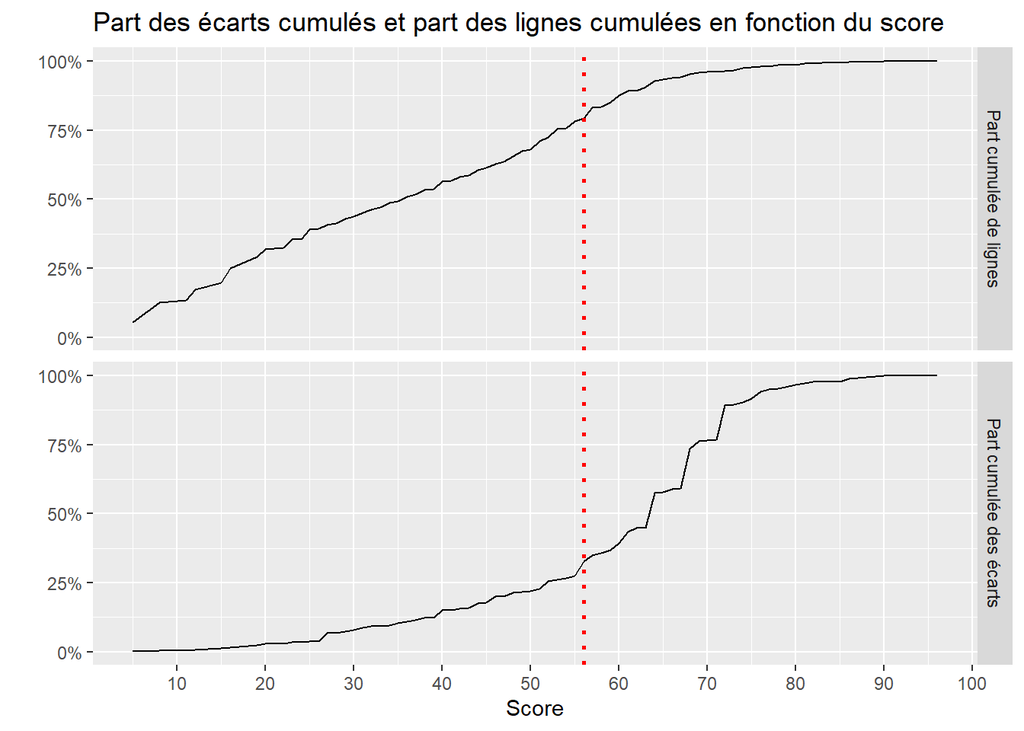

| Score | Montants cumulés des écarts | Part des montants cumulés des écarts | Nombre de lignes cumulées | Part de lignes cumulées |
| --- | --- | --- | --- | --- |
| 56 | 19943825 | 33% | 2063 | 79% |

[output not shown]